# Rush Hour Explorations

Assignment for PVG0038 Reproducibility in Research with a focus on data analysis using the program R

Alexander Koc (alexander.koc@slu.se)

2020-11-06

## Summary

In this short report I investigate the value of adding two new features to the Kaggle bikeshare data set: `hour` denoting hour of day and boolean variable `rush_hour` to denote if the current hour is during rush hour or not. The two variables will be evaluated together with the remaining predictors by fitting a random model forest and extracting variable importance metrics.

This document and associated files required for re-running the analysis can be downloaded from: https://github.com/alkc/project-reproducibility

## Data

The data set contains historical usage patterns for the Capital Bikeshare program in Washington, D.C., together with weather data. The purpose of the Kaggle competition in which this data set was made available was to forecast bike rental demand in the program (Fanaee-T and Gama 2014).

## Packages

All analysis below will be conducted in the statistical programming language R (R Core Team 2020). The data exploration and model fit will rely heavily on the `tidyverse` family of packages (Wickham et al. 2019) and the modeling package (Kuhn 2020). Random forest models will be fit using `ranger` (Wright and Ziegler 2017). Correlation plot will be constructed using `corrplot` (Wei and Simko 2017). Other utility packages include `here` (Müller 2017), `parallel` (R Core Team 2020), `forcats` (Wickham 2020) and `lubridate` (Grolemund and Wickham 2011). For a full specification of R and package versions used in creating this document, please refer to the session info

## Results

### Data preparation

Set random seed for reproducibility.

```r
set.seed(777)
```

To install all packages required for analysis, please run the following command in R from the project directory: `source("install_dependencies.R")`

```r
library(tidyverse)
library(corrplot)
library(caret)
library(lubridate)
library(here)
library(parallel)
library(ranger)
library(forcats)

# Set number of cores for parallel computation
nbr_cores <- parallel::detectCores()

# Create variable specification for dataset:
col_spec <- cols(
  .default = col_double(),
  datetime = col_datetime(format = ""),
  season = col_integer(),
  holiday = col_logical(),
  workingday = col_logical(),
  weather = col_factor(),
  count = col_integer()
)

bikeshare <- read_csv(here::here("data/train.csv"), col_types = col_spec)
```

We drop the `casual` and `registered` columns, as they add up to the `count` column anyway – making it a linear combination of both.

```r
bikeshare <- bikeshare %>%
  select(-registered, -casual)
```

Expand season names to text labels – we have the computer memory and screen real estate to spare:

```r
bikeshare <- bikeshare %>%
  mutate(season = map_chr(season, function(season_code) {

    seasons <- c("spring" = 1, "summer" = 2,  "fall" = 3, winter = "4")
    translated_name <- names(seasons[season_code])

    # (I guess map_chr would catch this anyway?)
    if(is.na(translated_name)) {
      err <- paste("Invalid season code:", season_code)
      stop(err)
    }

    return(translated_name)

  }))

# Convert back to factor:
bikeshare$season <- as.factor(bikeshare$season)
```

Expand some column names to spell out what they actually are and rename others to make data set look nicer.

```r
bikeshare <-  bikeshare %>%
  rename(
    date_time = datetime,
    working_day = workingday,
    temp_celcius = temp,
    feels_like_temp_celcius = atemp,
    relative_humidity = humidity,
    wind_speed = windspeed,
    total_nbr_rentals = count
  )
```

Finally, the hour at which bikes are rented *feels* like it should have some predictive power. Split the date time into a time column:

```r
bikeshare <- bikeshare %>%
  mutate(hour = hour(date_time)) %>%
  select(date_time, hour, everything())
```

Probably good idea to create another column that specified which day of the week it is. A weekend starts after working hours on a friday, and I hypothesize there will be more bike sharing activity on a friday evening -> midnight compared to other weekdays. Out of the scope for this assignment though.

Final data set:

```r
glimpse(bikeshare)
```

```
## Rows: 10,886
## Columns: 11
## $ date_time               <dttm> 2011-01-01 00:00:00, 2011-01-01 01:00:00, ...
## $ hour                    <int> 0, 1, 2, 3, 4, 5, 6, 7, 8, 9, 10, 11, 12, 1...
## $ season                  <fct> spring, spring, spring, spring, spring, spr...
## $ holiday                 <lgl> FALSE, FALSE, FALSE, FALSE, FALSE, FALSE, F...
## $ working_day             <lgl> FALSE, FALSE, FALSE, FALSE, FALSE, FALSE, F...
## $ weather                 <fct> 1, 1, 1, 1, 1, 2, 1, 1, 1, 1, 1, 1, 1, 2, 2...
## $ temp_celcius            <dbl> 9.84, 9.02, 9.02, 9.84, 9.84, 9.84, 9.02, 8...
## $ feels_like_temp_celcius <dbl> 14.395, 13.635, 13.635, 14.395, 14.395, 12....
## $ relative_humidity       <dbl> 81, 80, 80, 75, 75, 75, 80, 86, 75, 76, 76,...
## $ wind_speed              <dbl> 0.0000, 0.0000, 0.0000, 0.0000, 0.0000, 6.0...
## $ total_nbr_rentals       <int> 16, 40, 32, 13, 1, 1, 2, 3, 8, 14, 36, 56, ...
```

### Data exploration

#### Data summary

```r
summary(bikeshare)
```

```
##    date_time                        hour          season      holiday
##  Min.   :2011-01-01 00:00:00   Min.   : 0.00   fall  :2733   Mode :logical
##  1st Qu.:2011-07-02 07:15:00   1st Qu.: 6.00   spring:2686   FALSE:10575
##  Median :2012-01-01 20:30:00   Median :12.00   summer:2733   TRUE :311
##  Mean   :2011-12-27 05:56:22   Mean   :11.54   winter:2734
##  3rd Qu.:2012-07-01 12:45:00   3rd Qu.:18.00
##  Max.   :2012-12-19 23:00:00   Max.   :23.00
##  working_day     weather   temp_celcius   feels_like_temp_celcius
##  Mode :logical   1:7192   Min.   : 0.82   Min.   : 0.76
##  FALSE:3474      2:2834   1st Qu.:13.94   1st Qu.:16.66
##  TRUE :7412      3: 859   Median :20.50   Median :24.24
##                  4:   1   Mean   :20.23   Mean   :23.66
##                           3rd Qu.:26.24   3rd Qu.:31.06
##                           Max.   :41.00   Max.   :45.45
##  relative_humidity   wind_speed     total_nbr_rentals
##  Min.   :  0.00    Min.   : 0.000   Min.   :  1.0
##  1st Qu.: 47.00    1st Qu.: 7.002   1st Qu.: 42.0
##  Median : 62.00    Median :12.998   Median :145.0
##  Mean   : 61.89    Mean   :12.799   Mean   :191.6
##  3rd Qu.: 77.00    3rd Qu.:16.998   3rd Qu.:284.0
##  Max.   :100.00    Max.   :56.997   Max.   :977.0
```

Seems like there is only one row with weather code “4”. Remove it:

```r
bikeshare <- bikeshare %>%
  filter(weather != 4)

# Drop unused factor level to avoid annoying messages later:
bikeshare$weather <- forcats::fct_drop(bikeshare$weather)
```

Check for correlation between counts and numeric variables

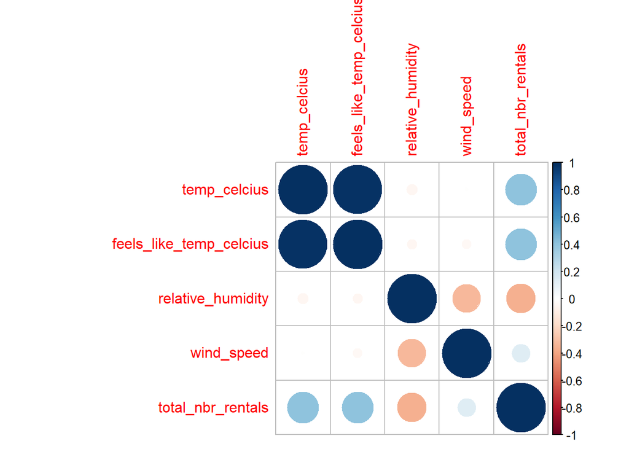

```r
cor_mat <- bikeshare %>%
  select(where(is.numeric), -hour) %>%
  cor(method = "spearman") %>%
  corrplot()
```

The two temperature variables are practically the same:

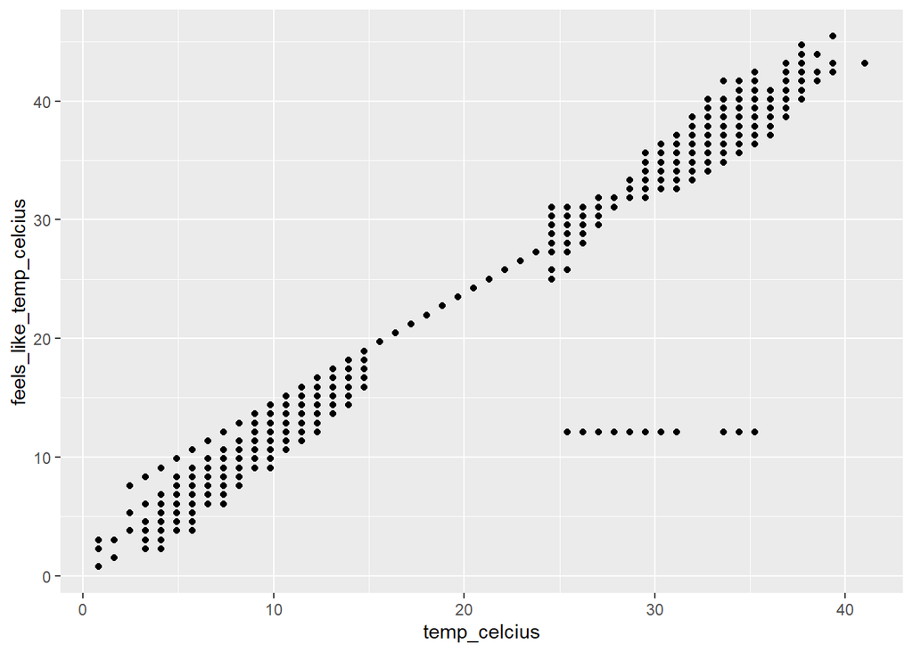

```r
bikeshare %>%
  ggplot(aes(y = feels_like_temp_celcius, x = temp_celcius)) +
  geom_point()
```

Uhh, except that really weird horizontal line. What’s going on? Let’s look at that interval.

```r
bikeshare %>%
  filter(temp_celcius > 25 & temp_celcius < 36) %>%
  filter(feels_like_temp_celcius < 25) %>%
  select(date_time, temp_celcius, feels_like_temp_celcius)
```

```
## # A tibble: 24 x 3
##    date_time           temp_celcius feels_like_temp_celcius
##    <dttm>                     <dbl>                   <dbl>
##  1 2012-08-17 00:00:00         27.9                    12.1
##  2 2012-08-17 01:00:00         27.1                    12.1
##  3 2012-08-17 02:00:00         27.1                    12.1
##  4 2012-08-17 03:00:00         26.2                    12.1
##  5 2012-08-17 04:00:00         26.2                    12.1
##  6 2012-08-17 05:00:00         26.2                    12.1
##  7 2012-08-17 06:00:00         25.4                    12.1
##  8 2012-08-17 07:00:00         26.2                    12.1
##  9 2012-08-17 08:00:00         27.9                    12.1
## 10 2012-08-17 09:00:00         28.7                    12.1
## # ... with 14 more rows
```

Seems like a wrong value was propagated for the entire day. Here I would try to delete that the wrong temperature values and impute new values. No time for that though – this time we just delete:

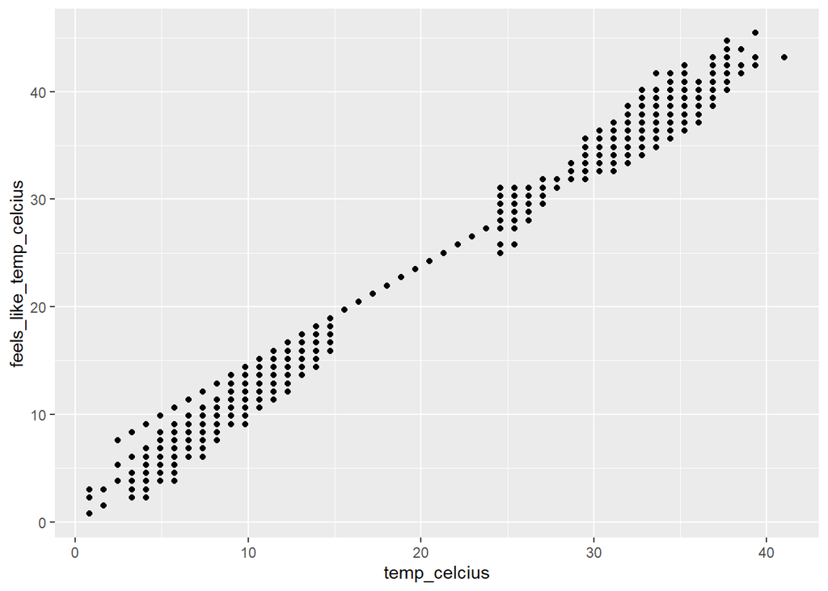

```r
bikeshare <- bikeshare %>%
  filter(!(temp_celcius > 25 & temp_celcius < 36 & feels_like_temp_celcius > 10 & feels_like_temp_celcius < 15))

bikeshare %>%
  ggplot(aes(y = feels_like_temp_celcius, x = temp_celcius)) +
  geom_point()
```

#### Missingness

Check for missing data:

```r
# Returns true is there are _any_ missing values in the data frame
bikeshare %>%
  is.na %>%
  any()
```

```
## [1] FALSE
```

No missing data.

### Adding new features

#### `hour`

Visualize total number of rentals by daily hour – the new variable introduced earlier in code.

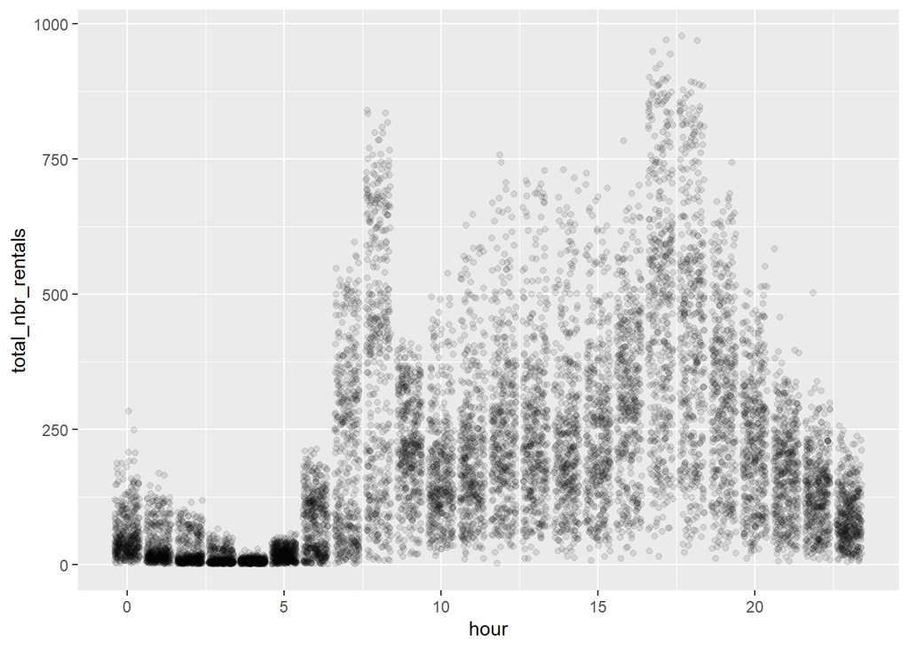

```r
bikeshare %>%
  ggplot(aes(x = hour, y = total_nbr_rentals)) +
  geom_jitter(alpha = 0.1)
```

Clear peak of rides around rush hours. Investigate to see if there is an interaction with the workday variable.

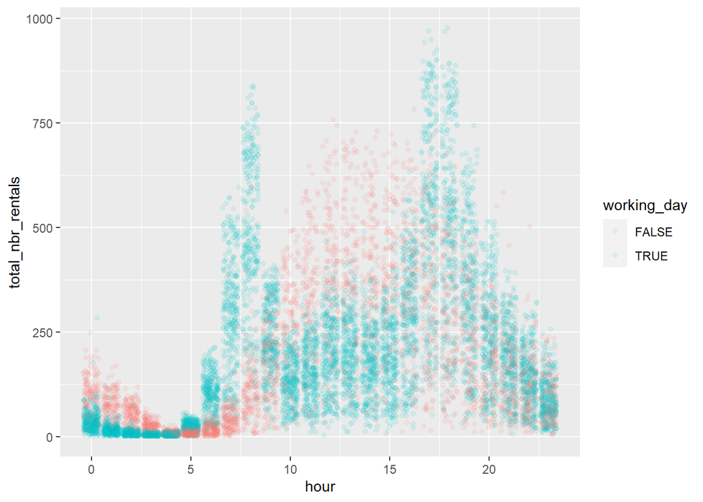

```r
bikeshare %>%
  ggplot(aes(x = hour, y = total_nbr_rentals, color = working_day)) +
  geom_jitter(alpha = 0.1)
```

Split up the plot above into two plots and the pattern becomes more clear. Rush hour peaks of course exist on working days. Weekends seem to have more bike share activity in the hours on and after midnight.

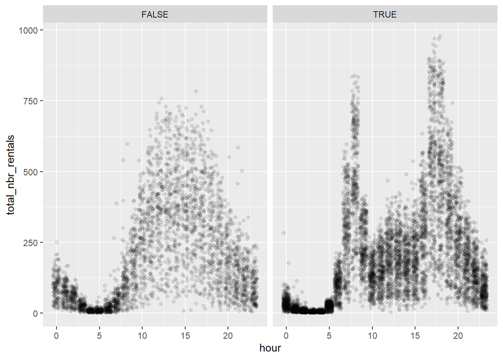

```r
bikeshare %>%
  ggplot(aes(x = hour, y = total_nbr_rentals)) +
  geom_jitter(alpha = 0.1) +
  facet_wrap(~working_day)
```

#### `rush_hour`

Create new boolean variable `rush_hour` by intersecting all hours between 05-10 and 15-19 when `working_day == TRUE`:

```r
bikeshare <- bikeshare %>%
  mutate(rush_hour = map2_lgl(hour, working_day, function(hour, working) {

    # If not working day then no rush hour
    if(working == FALSE) {
      return(FALSE)
    }

    if((5 < hour & hour < 10) | (15 < hour & hour < 19)) {
      return(TRUE)
    }

    return(FALSE)

  }))
```

How does the new feature describe the data?

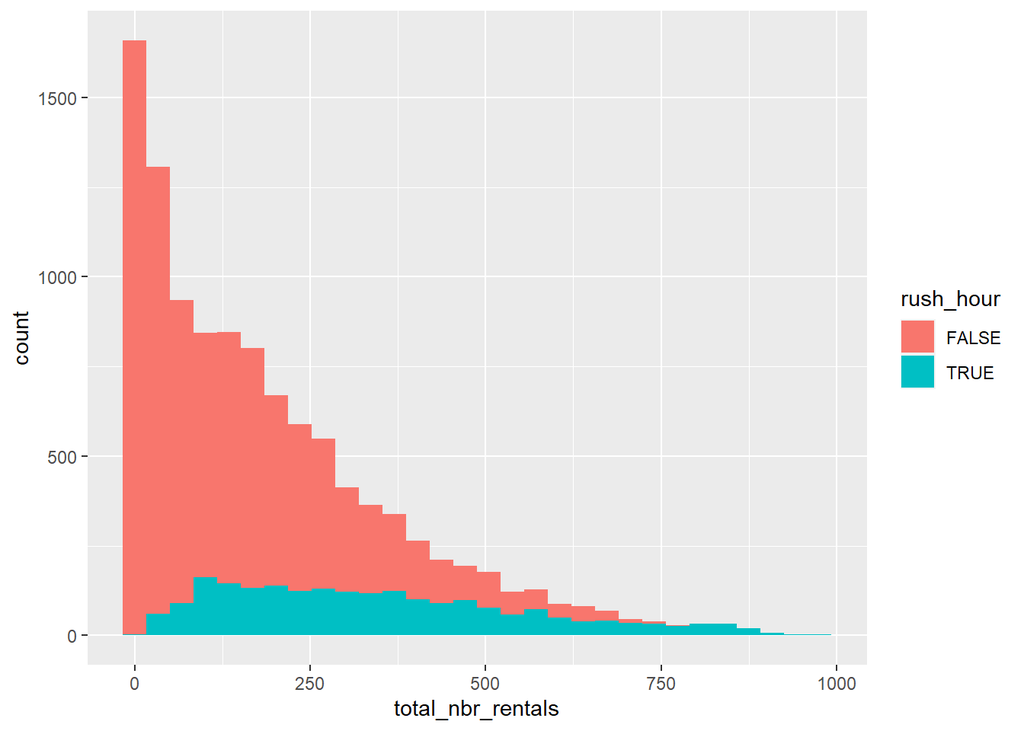

```r
bikeshare %>%
  ggplot(aes(fill = rush_hour, x = total_nbr_rentals)) +
  geom_histogram()
```

Less counts distributed around 0 for rush hour hours.

#### Interactions of new features with other features

Continue looking at rides per hour, but this time split by seasons and weather

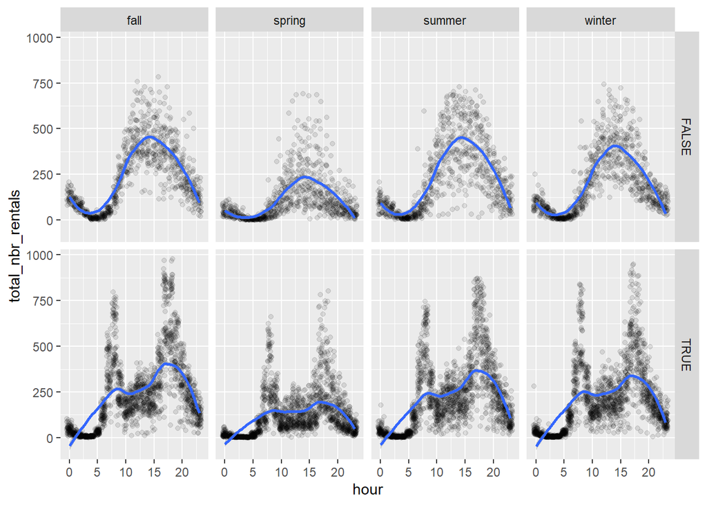

```r
bikeshare %>%
  ggplot(aes(x = hour, y = total_nbr_rentals)) +
  geom_jitter(alpha = 0.1) +
  geom_smooth(method = "loess") +
  facet_grid(rows = vars(working_day), cols = vars(season))
```

Again, what is it about spring? Not much visual difference between other seasons. Even seems like spring has effect on weekday bike shares.

Next up, split by weather.

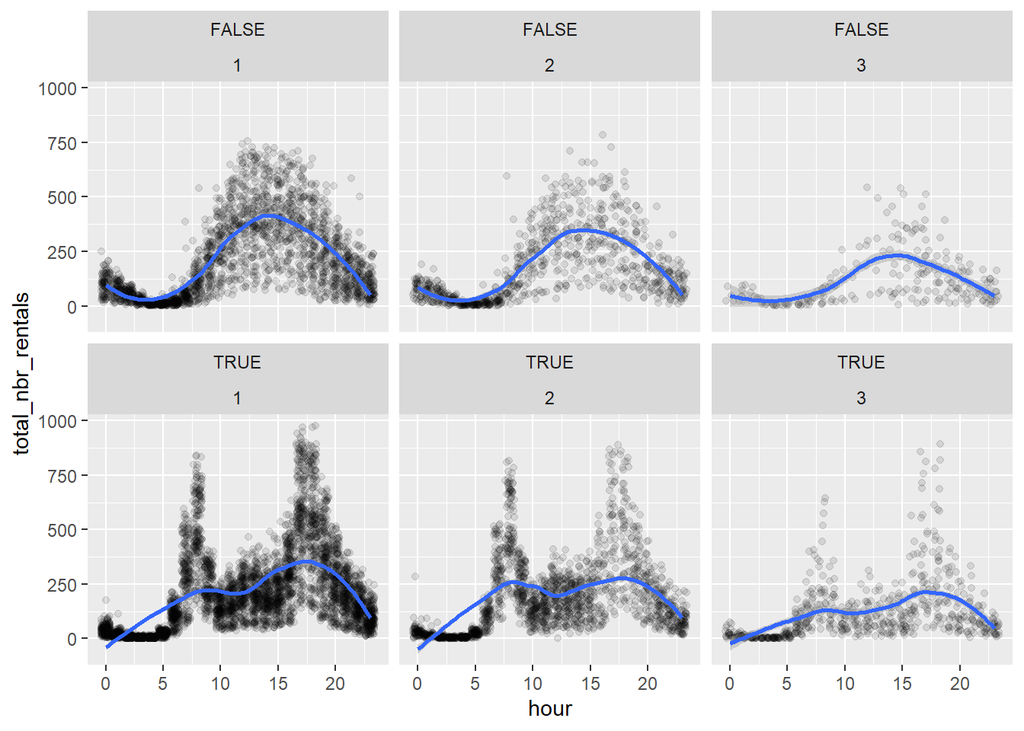

```r
bikeshare %>%
  ggplot(aes(x = hour, y = total_nbr_rentals)) +
  geom_jitter(alpha = 0.1) +
  geom_smooth(method = "loess") +
  facet_wrap(~working_day + weather)
```

Unbalanced data with worsening weather, but *if* plots are to be believed then less rides in bad weather.

Could look more into how weather types interact with seasons.

Look at temperature:

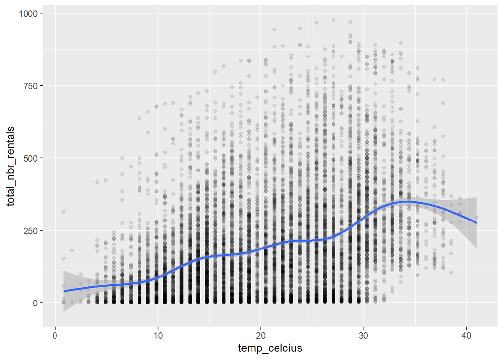

```r
bikeshare %>%
  ggplot(aes(x = temp_celcius, y = total_nbr_rentals)) +
  geom_point(alpha = 0.1) +
  geom_smooth()
```

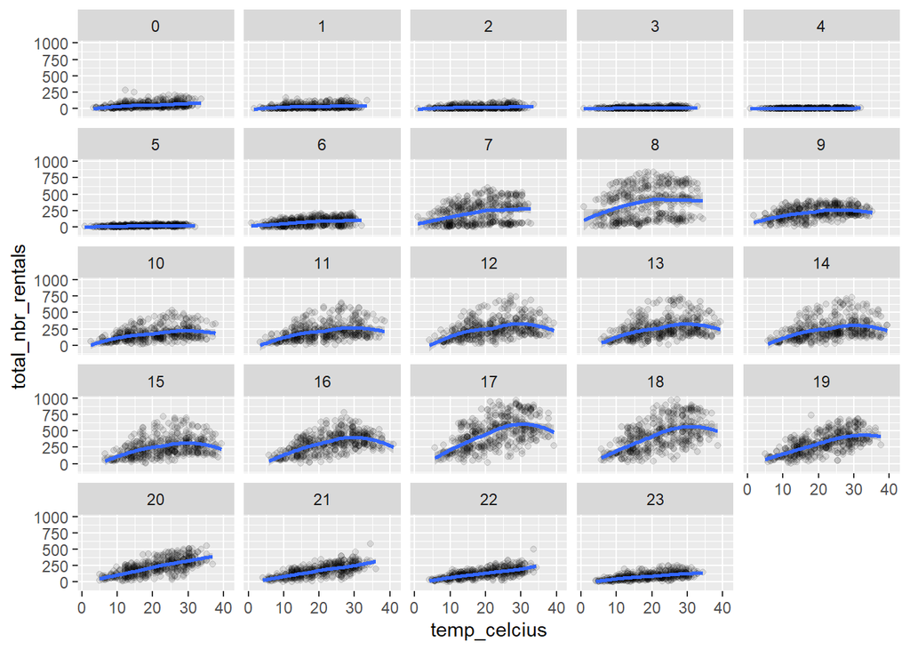

```r
bikeshare %>%
  ggplot(aes(x = temp_celcius, y = total_nbr_rentals)) +
  geom_point(alpha = 0.1) +
  geom_smooth() +
  facet_wrap(~hour)
```

The effect of temperature is specific to which hour it is, sort of. Guessing there is *probably* an interaction with season and weather, not to mention humidity here. Outside the scope of this course though.

How about wind speed?

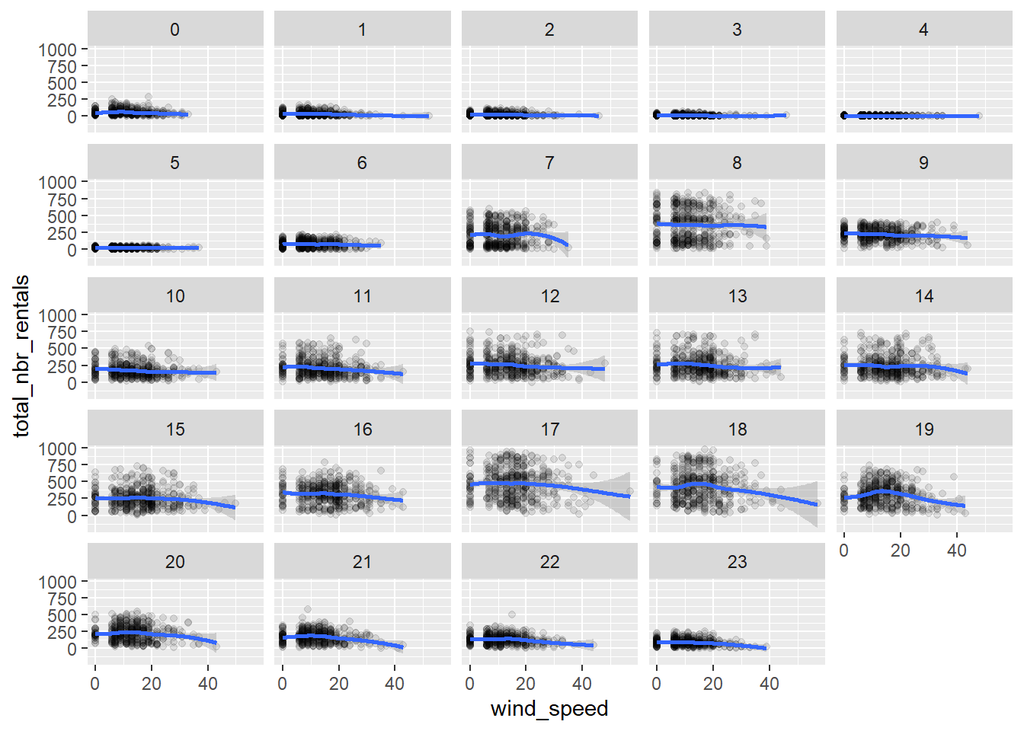

```r
bikeshare %>%
  ggplot(aes(x = wind_speed, y = total_nbr_rentals)) +
  geom_point(alpha = 0.1) +
  geom_smooth() +
  facet_wrap(~hour)
```

Nothing as clear as the temperature effect by hour.

### Model

We will fit a random forest model using caret. Best model will be selected on basis of 5-fold cross validation. Variable importance will be assessed by extracting variable importance metrics from final model and plotting.

```r
train_control <- trainControl(method = "repeatedcv", number = 5, repeats = 0, verboseIter = FALSE, allowParallel = TRUE)
```

Remove the `date_time` column and fit model using all predictor variables. Use `ranger` for parallel random forest model fit. Predictors are centered and scaled.

```r
# This might take a few minutes to run!
fit_mod <- bikeshare %>%
  select(-date_time) %>%
  train(total_nbr_rentals ~ ., data = ., method = "ranger", trControl = train_control, preProcess = c("center", "scale"), num.threads = nbr_cores, importance = "impurity")

fit_mod
```

```
## Random Forest
##
## 10861 samples
##    10 predictor
##
## Pre-processing: centered (13), scaled (13)
## Resampling: Cross-Validated (5 fold, repeated 0 times)
## Summary of sample sizes: 8688, 8689, 8689, 8689, 8689, 8688, ...
## Resampling results across tuning parameters:
##
##   mtry  splitrule   RMSE       Rsquared   MAE
##    2    variance     91.15712  0.7785425  63.50726
##    2    extratrees  105.68179  0.7270779  77.63273
##    7    variance     68.61579  0.8567883  45.43356
##    7    extratrees   69.15438  0.8554327  46.26959
##   13    variance     69.83517  0.8516202  45.93592
##   13    extratrees   69.17982  0.8544519  45.98188
##
## Tuning parameter 'min.node.size' was held constant at a value of 5
## RMSE was used to select the optimal model using the smallest value.
## The final values used for the model were mtry = 7, splitrule = variance
##  and min.node.size = 5.
```

Extract and plot the variable importance metrics for predictors:

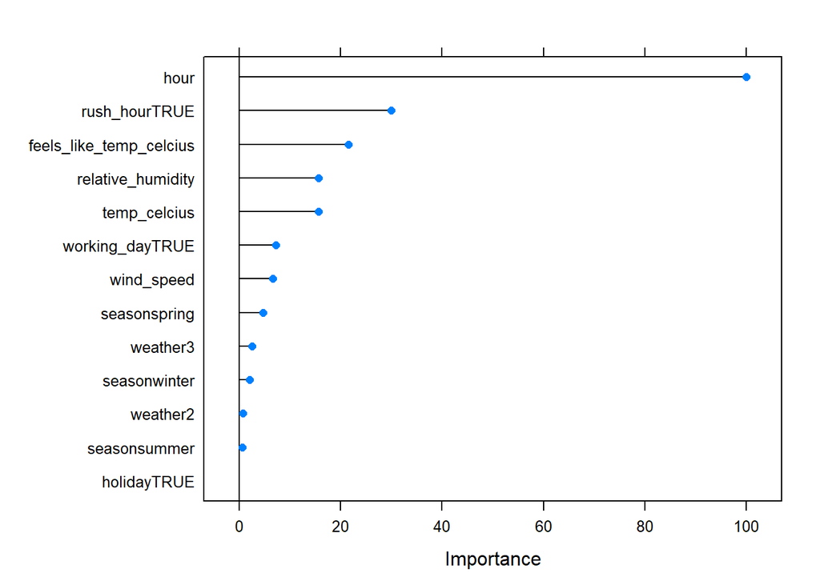

```r
variable_importance <- varImp(fit_mod)
plot(variable_importance)
```

The two added features `hour` and `rush_hour` are at the top of the variable importance plot.

## Session

Packages and R version used in my analysis.

[session information not shown]

## References

Fanaee-T, Hadi, and Joao Gama. 2014. “Event Labeling Combining Ensemble Detectors and Background Knowledge.” *Progress in Artificial Intelligence* 2 (2): 113–27. https://doi.org/10.1007/s13748-013-0040-3.

Grolemund, Garrett, and Hadley Wickham. 2011. “Dates and Times Made Easy with lubridate.” *Journal of Statistical Software* 40 (3): 1–25. http://www.jstatsoft.org/v40/i03/.

Kuhn, Max. 2020. *Caret: Classification and Regression Training*. https://CRAN.R-project.org/package=caret.

Müller, Kirill. 2017. *Here: A Simpler Way to Find Your Files*. https://CRAN.R-project.org/package=here.

R Core Team. 2020. *R: A Language and Environment for Statistical Computing*. Vienna, Austria: R Foundation for Statistical Computing. https://www.R-project.org/.

Wei, Taiyun, and Viliam Simko. 2017. *R Package "Corrplot": Visualization of a Correlation Matrix*. https://github.com/taiyun/corrplot.

Wickham, Hadley. 2020. *Forcats: Tools for Working with Categorical Variables (Factors)*. https://CRAN.R-project.org/package=forcats.

Wickham, Hadley, Mara Averick, Jennifer Bryan, Winston Chang, Lucy D’Agostino McGowan, Romain François, Garrett Grolemund, et al. 2019. “Welcome to the tidyverse.” *Journal of Open Source Software* 4 (43): 1686. https://doi.org/10.21105/joss.01686.

Wright, Marvin N., and Andreas Ziegler. 2017. “ranger: A Fast Implementation of Random Forests for High Dimensional Data in C++ and R.” *Journal of Statistical Software* 77 (1): 1–17. https://doi.org/10.18637/jss.v077.i01.